# Predict T cell dysfunction genes from TCGA Pancreatic Cancer Cohort

Yufan Zhou

12 December, 2019

### Introduction

Chimeric antigen receptor (CAR) T cells have been genetically engineered to express a receptor that recognizes a specific antigen, have given rise to breakthroughs in treating hematological malignancies. However, their success in treating solid tumors has been limited. T cells that enter solid tumors can stop working due to a phenomenon called T cell dysfunction. T cell dysfunction is a hallmark of many cancers. Identifying and overcoming mechanisms associated with dysfunction in CAR T cells is of vital importance to generating CAR T cells that can proliferate and successfully eliminate tumor cells.

Gene expression biomarkers in T cells, such as PDCD1, HACVR2, LAG3, TOX, EOMES, CTLA4, CD8A have been demonstrated in mouse model to predict CAR T treatment benefits. However, current CAR T clinical trials have gene expression profiles on only a small number of samples, which are insufficient to uncover prognostic biomarkers. Alternatively, there are many public tumor profiling datasets from human clinical trials. Some specimens have high level of infiltration by cytotoxic T cells and poor survival rate, and T cells in these specimens tend to be in a dysfunctional state. Analyzing TCGA dataset might uncover uncharacterized T cell dysfunction genes. Identification of reproducible biomarkers that can be applied to enhance CAR T cell persistance.

### Methods

1. Correlation analysis

2. Survival analysis

Kaplan–Meier curves were constructed by dividing specimens at the one standard deviation above or below average expression of each selected gene. Overall survival (OS) data were available for all 222 patients.

3. Differential gene expression

Differential gene expression was performed with Limma. Limma-voom was used to identify transcripts that were significantly differntially expressed between experimental groups using adjusted P value of <0.05.

4. GO and KEGG analysis

Gene ontology (http://www.geneontology.org/) provides a controlled vocabulary for describing biological processes (BP ontology), molecular functions (MF ontology) and cellular components (CC ontology). KEGG mapping is the process to map genes to molecular interaction/reaction/relation networks.

This report shows the process of discovering potential T cell dysfunction genes from TCGA cohort, including:

- Data preprocess
- Correlation analysis
- Differential gene expression analysis
- GO and KEGG Analysis
- Survival analysis

Load the necessary libraries.

```r
library(knitr)
library(pander)
library(biomaRt)
library(curl)
library(VennDiagram)
library(stringr)
library(edgeR)
library(RColorBrewer)
library(biomaRt)
library(DOSE)
library(org.Hs.eg.db)
library(topGO)
library(clusterProfiler)
library(pathview)
library(curl)
library(pheatmap)
library(RColorBrewer)
library(ggplot2)
library(tidyverse)
library(survival)
library(survminer)
library(viridis)
```

## Data Preprocess

**Datasets:**

- Transformed FPKM normalized count (n=182)
- Transformed RSEM normalized count (n=183)
- Survival data (n=222)
- Phenotype data (n=222)

Dataset were downloaded from GDC TCGA Pancreatic Cancer cohort: https://xenabrowser.net/datapages/

All gene expression data was log2(x+1) transformed

**Biomarkers:**

T cell dysfunction biomarkers: **CD8A, HAVCR2, LAG3, PDCD1, EOMES, TBX21,CTLA4** have been demonstrated in pre-clinical model to predict T cell dysfunction

## Correlation Analysis

### Load Dataset

```r
data <- read.table(gzfile("./Data/TCGA-PAAD.htseq_fpkm.tsv.gz"), sep="\t", header=TRUE, stringsAsFactors=FALSE)
data[1:6, 1:10]
```

```
##           Ensembl_ID TCGA.3A.A9IO.01A TCGA.US.A774.01A TCGA.HZ.A49H.01A
## 1  ENSG00000242268.2         2.598581      0.000000000      0.000000000
## 2  ENSG00000270112.3         0.000000      0.005231866      0.006301543
## 3 ENSG00000167578.15         3.185784      2.114021318      2.537940926
## 4  ENSG00000273842.1         0.000000      0.000000000      0.000000000
## 5  ENSG00000078237.5         2.611911      2.272382321      2.187969851
## 6 ENSG00000146083.10         2.935777      3.519089598      2.797442562
##   TCGA.FB.A4P5.01A TCGA.FB.AAPS.01A TCGA.3A.A9IN.01A TCGA.HV.A5A5.01A
## 1       0.13375715      0.103072765       1.50504076       0.39995089
## 2       0.01931689      0.007393497       0.08477994       0.02814571
## 3       2.84486922      2.583773011       2.89737226       2.53471021
## 4       0.00000000      0.000000000       0.00000000       0.00000000
## 5       2.38118928      1.865470138       1.41997909       2.27349141
## 6       3.54387016      3.159257101       3.55247589       3.51170543
##   TCGA.H6.A45N.11A TCGA.H6.8124.01A
## 1      0.057114331       0.03491978
## 2      0.008061188       0.00000000
## 3      3.464075918       2.15259991
## 4      0.000000000       0.00000000
## 5      2.275374677       1.68239630
## 6      5.312419169       3.63178033
```

```r
# remove decimal of Ensembl_ID
data_modified <- sapply(strsplit(data$Ensembl_ID,"\\."), function(x) x[1])
data_new <- cbind(data_modified, data)
data_new <- data_new[, -2]

library(dplyr)
data2 <- data_new %>% dplyr::rename(ensembl_gene_id = data_modified)
```

### Annotation

Use ensembl gene id to annotate gene name.

Remove NA gene.

Simplify sample name to arabic numerals “1,2,3..182”.

Parts of annotated dataframe

|  | Symbol | 1 | 2 | 3 | 4 | 5 | 6 | 7 | 8 | 9 |
| --- | --- | --- | --- | --- | --- | --- | --- | --- | --- | --- |
| **1** | LINC02082 | 2.599 | 0 | 0 | 0.1338 | 0.1031 | 1.505 | 0.4 | 0.05711 | 0.03492 |
| **2** | AC090241.2 | 0 | 0.005232 | 0.006302 | 0.01932 | 0.007393 | 0.08478 | 0.02815 | 0.008061 | 0 |
| **3** | RAB4B | 3.186 | 2.114 | 2.538 | 2.845 | 2.584 | 2.897 | 2.535 | 3.464 | 2.153 |
| **5** | TIGAR | 2.612 | 2.272 | 2.188 | 2.381 | 1.865 | 1.42 | 2.273 | 2.275 | 1.682 |
| **6** | RNF44 | 2.936 | 3.519 | 2.797 | 3.544 | 3.159 | 3.552 | 3.512 | 5.312 | 3.632 |
| **7** | NUP210P2 | 0 | 0 | 0 | 0 | 0 | 0 | 0 | 0 | 0 |

### Correlation Analysis

Spearman’s rank correlation test will be used to assess the strength of the relationship between each classical T cell biomarkers with rest of 60,000 genes.

**Biomarker CD8A, HAVCR2, LAG3, PDCD1, EOMES, TBX21, CTLA4 will be tested repectively.**

1. HAVCR2

```r
# set an empty dataframe
result_havcr2 <- data.frame((matrix(nrow = 56553, ncol = 2)))
colnames(result_havcr2) <- c("variable", "R")

# for loop to retreive R value

x <- data.frame(t(subset(data.clean, Symbol == "HAVCR2")[-1]))
colnames(x) <- subset(data.clean, Symbol == "HAVCR2")[,1]

for (i in 1:56553){
  y = data.frame(t(subset(data.clean[i,])[-1]))
  colnames(y) <- subset(data.clean[i,])[,1]
  res_havcr2 <- cor.test(x$HAVCR2, y[1:182,1], method = "spearman", exact=F)
  result_havcr2[i,2] <- res_havcr2$estimate
  result_havcr2[i,1] <- as.character(data.clean[i,1])
}
result_havcr2
write.csv(result_havcr2, file = "./correlation_result/result_havcr2.csv")
```

2. PDCD1

```r
# set an empty dataframe
result_pdcd1 <- data.frame((matrix(nrow = 56553, ncol = 2)))
colnames(result_pdcd1) <- c("variable", "R")

# for loop to retreive R value

x <- data.frame(t(subset(data.clean, Symbol == "PDCD1")[-1]))
colnames(x) <- subset(data.clean, Symbol == "PDCD1")[,1]

for (i in 1:56553){
  y = data.frame(t(subset(data.clean[i,])[-1]))
  colnames(y) <- subset(data.clean[i,])[,1]
  res_pdcd1 <- cor.test(x$PDCD1, y[1:182,1], method = "spearman", exact=F)
  result_pdcd1[i,2] <- res_pdcd1$estimate
  result_pdcd1[i,1] <- as.character(data.clean[i,1])
}
result_pdcd1
write.csv(result_pdcd1, file = "./correlation_result/result_pdcd1.csv")
```

3. LAG3

```r
# set an empty dataframe
result_lag3 <- data.frame((matrix(nrow = 56553, ncol = 2)))
colnames(result_lag3) <- c("variable", "R")

# for loop to retreive R value

x <- data.frame(t(subset(data.clean, Symbol == "LAG3")[-1]))
colnames(x) <- subset(data.clean, Symbol == "LAG3")[,1]

for (i in 1:56553){
  y = data.frame(t(subset(data.clean[i,])[-1]))
  colnames(y) <- subset(data.clean[i,])[,1]
  res_lag3 <- cor.test(x$LAG3, y[1:182,1], method = "spearman", exact=F)
  result_lag3[i,2] <- res_lag3$estimate
  result_lag3[i,1] <- as.character(data.clean[i,1])
}
result_lag3
write.csv(result_lag3, file = "./correlation_result/result_lag3.csv")
```

4. TBX21

```r
# set an empty dataframe
result_tbx21 <- data.frame((matrix(nrow = 56553, ncol = 2)))
colnames(result_tbx21) <- c("variable", "R")

# for loop to retreive R value

x <- data.frame(t(subset(data.clean, Symbol == "TBX21")[-1]))
colnames(x) <- subset(data.clean, Symbol == "TBX21")[,1]

for (i in 1:56553){
  y = data.frame(t(subset(data.clean[i,])[-1]))
  colnames(y) <- subset(data.clean[i,])[,1]
  res_tbx21 <- cor.test(x$TBX21, y[1:182,1], method = "spearman", exact=F)
  result_tbx21[i,2] <- res_tbx21$estimate
  result_tbx21[i,1] <- as.character(data.clean[i,1])
}
result_tbx21
write.csv(result_tbx21, file = "./correlation_result/result_tbx21.csv")
```

5. EOMES

```r
# set an empty dataframe
result_eomes <- data.frame((matrix(nrow = 56553, ncol = 2)))
colnames(result_eomes) <- c("variable", "R")

# for loop to retreive R value

x <- data.frame(t(subset(data.clean, Symbol == "EOMES")[-1]))
colnames(x) <- subset(data.clean, Symbol == "EOMES")[,1]

for (i in 1:56553){
  y = data.frame(t(subset(data.clean[i,])[-1]))
  colnames(y) <- subset(data.clean[i,])[,1]
  res_eomes <- cor.test(x$EOMES, y[1:182,1], method = "spearman", exact=F)
  result_eomes[i,2] <- res_eomes$estimate
  result_eomes[i,1] <- as.character(data.clean[i,1])
}
result_eomes
write.csv(result_eomes, file = "./correlation_result/result_eomes.csv")
```

6. CTLA4

```r
# set an empty dataframe
result_ctla4 <- data.frame((matrix(nrow = 56553, ncol = 2)))
colnames(result_ctla4) <- c("variable", "R")

# for loop to retreive R value

x <- data.frame(t(subset(data.clean, Symbol == "CTLA4")[-1]))
colnames(x) <- subset(data.clean, Symbol == "CTLA4")[,1]

for (i in 1:56553){
  y = data.frame(t(subset(data.clean[i,])[-1]))
  colnames(y) <- subset(data.clean[i,])[,1]
  res_ctla4 <- cor.test(x$CTLA4, y[1:182,1], method = "spearman", exact=F)
  result_ctla4[i,2] <- res_ctla4$estimate
  result_ctla4[i,1] <- as.character(data.clean[i,1])
}
result_ctla4
write.csv(result_ctla4, file = "./correlation_result/result_ctla4.csv")
```

7. CD8A

```r
# set an empty dataframe
result_cd8a <- data.frame((matrix(nrow = 56553, ncol = 2)))
colnames(result_cd8a) <- c("variable", "R")

# for loop to retreive R value

x <- data.frame(t(subset(data.clean, Symbol == "CD8A")[-1]))
colnames(x) <- subset(data.clean, Symbol == "CD8A")[,1]

for (i in 1:56553){
  y = data.frame(t(subset(data.clean[i,])[-1]))
  colnames(y) <- subset(data.clean[i,])[,1]
  res_cd8a <- cor.test(x$CD8A, y[1:182,1], method = "spearman", exact=F)
  result_cd8a[i,2] <- res_cd8a$estimate
  result_cd8a[i,1] <- as.character(data.clean[i,1])
}
result_cd8a
write.csv(result_cd8a, file = "./correlation_result/result_cd8a.csv")
```

### Overlapping Analysis for correlation results

**345 overlapping genes were selected out**,see the below dataframe

```
##   [1] "KBTBD8"     "BTLA"       "MCOLN2"     "WAS"        "TRAV16"
##   [6] "SLA"        "IL10RA"     "EOMES"      "GBP5"       "NCF1B"
##  [11] "GPR171"     "LIMD2"      "IL18BP"     "TREML1"     "CD96"
##  [16] "FUT7"       "AP005019.1" "CXCR2P1"    "TRAV1-1"    "PSTPIP1"
##  [21] "PLEKHO2"    "SEPTIN6"    "AF127936.1" "ABCD2"      "AC079630.1"
##  [26] "NRROS"      "CXCL9"      "FTH1P22"    "ADAP2"      "SUSD3"
##  [31] "ZAP70"      "LINC02611"  "TRGV10"     "NAPSB"      "NLRC3"
##  [36] "FYB1"       "LAIR1"      "SIT1"       "IFNG"       "EBI3"
##  [41] "TRIM22"     "RHOH"       "LINC00426"  "CALHM6"     "KLRB1"
##  [46] "FNBP1"      "LILRB1"     "DOCK2"      "ANTXRLP1"   "BIN2"
##  [51] "CD69"       "CD74"       "CD244"      "WDFY4"      "TRBV2"
##  [56] "GIMAP7"     "LINC02273"  "GNGT2"      "AL031846.1" "PREX1"
##  [61] "STAB1"      "ITPRIPL1"   "ICOS"       "TRAV8-3"    "TRAV8-6"
##  [66] "TRAV12-2"   "LAP3"       "AL365361.1" "GPR65"      "GZMH"
##  [71] "CD3D"       "RNF175"     "HCST"       "LCP2"       "TRBV12-3"
```

[output cut: 54 more lines]

**Venn diagram showed the number of overlapping genes from five biomarkers correlated gene sets**

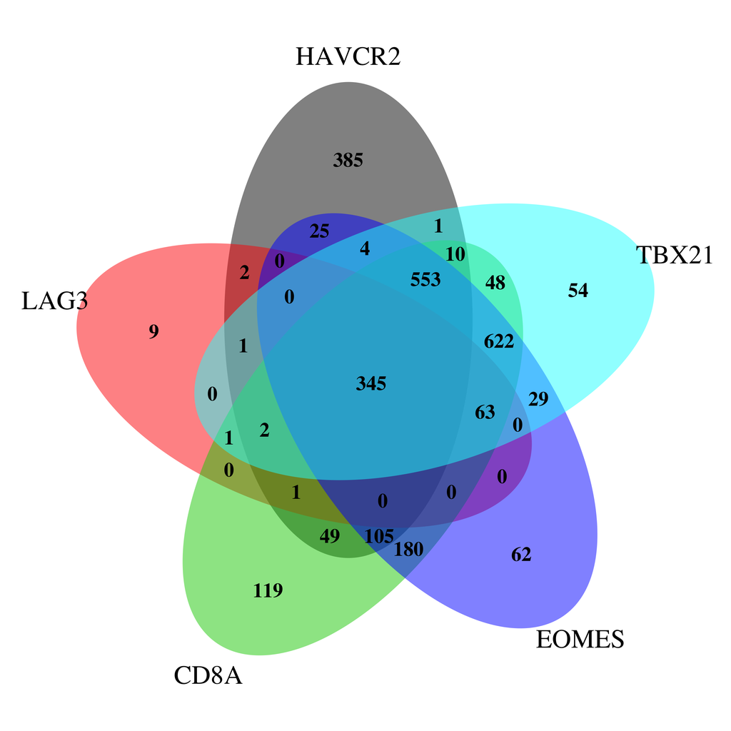

## Differential gene analysis

### Data preparation

Samples were ranked by overall survival time (os.time), and categorized into high survival group (75% percentile) and low survival group (25% percentile).

Simplify samples name to “H1,H2,..H45” and “L1, L2,..L44”

```
## [1] "integer"
```

```
##                H1      H2      H3      H4      H5      H6      H7      H8
## ARHGEF10L  9.5734 10.3872 10.1431 11.0212 10.4928 10.2869 10.6394  9.9895
## HIF3A      6.4428  5.5034  4.6491  8.2457  5.5330  7.5433  6.6492  5.3604
## RNF17      0.0000  0.0000  1.1814  3.9481  0.0000  3.2134  0.0000  0.0000
## RNF10     11.0862 11.6476 11.9355 12.0475 11.4720 11.5167 11.4528 11.9474
## RNF11      9.2096 10.4348 10.6350 10.7834 10.8523  9.8060 10.4746 10.7693
## RNF13      9.8581 10.1809 10.1076 10.0591 10.3007 10.5340 10.4383 10.1831
##                H9     H10     H11     H12     H13     H14     H15     H16
## ARHGEF10L 10.1822 10.1008 10.3257 10.5186 10.7643 10.7209 11.9851 10.3641
## HIF3A      7.8092  6.2037  6.2966  5.9351  7.3608  8.9113  7.1280  4.4201
## RNF17      0.0000  0.0000  0.0000  0.0000  0.4377  0.0000  0.6722  0.0000
## RNF10     11.0640 11.3253 11.9644 11.7311 11.8962 11.9497 12.1813 11.2958
## RNF11      9.9295 11.0621 10.3725 10.7823 10.3848 11.0643 10.2901 11.1965
## RNF13     10.0529 10.2809  9.6335  9.9883 10.3267 10.1166  9.7851 10.7190
##               H17     H18     H19     H20     H21     H22     H23     H24
## ARHGEF10L 10.0449 11.0835 10.3979 10.8880  8.5697 10.8393 10.4964  9.9452
## HIF3A      5.5475  4.2948  5.4643  5.5057  4.7299  8.9309  3.7979  5.2562
## RNF17      0.0000  0.0000  0.0000  0.0000  1.6054  0.0000  0.6427  0.0000
## RNF10     12.1250 12.2073 11.8464 12.1853 10.7241 11.7489 12.2124 11.7222
## RNF11     10.3938 10.9730 10.7660 10.8864  8.5928 10.6638 10.8055 11.0610
## RNF13     10.3339 10.1241 10.0915 10.3611  9.1650 10.5186 10.2347 11.3559
##               H25     H26     H27     H28     H29     H30     H31     H32
## ARHGEF10L 11.2540 11.1001 10.6203 10.0768 10.5240 10.8221 10.0709 10.8150
## HIF3A      8.4922  8.1557  8.9291  4.7171  2.9148  6.1464  6.4813  5.1758
## RNF17      0.0000  0.0000  0.0000  0.5149  0.0000  0.0000  0.0000  0.0000
## RNF10     11.7585 11.9380 11.5523 11.3744 11.5449 11.6661 12.0916 11.9976
## RNF11     11.1410 10.6974  9.9484 11.3110 11.4019 10.7213 10.9209 10.5836
## RNF13      9.7031 10.0114  9.6449 10.7624 10.3864 10.0361 10.2176 10.0453
##               H33     H34     H35     H36     H37     H38     H39     H40
## ARHGEF10L 10.6620  9.6549  9.8362  9.9362  9.9085 10.2838 10.5468 10.8905
## HIF3A      5.3576  7.3323  7.7463  8.0581  6.8751  4.4188  7.4437  6.7900
## RNF17      0.0000  0.0000  0.5016  0.4584  0.4941  1.2571  0.9819  0.0000
## RNF10     11.6730 11.5240 11.4613 11.6517 11.9301 11.6229 11.6264 11.9647
## RNF11     10.7457 11.1752 11.2304 10.5423 10.9372 10.6170 10.7569 11.5456
## RNF13      9.9054 10.9078 10.9347 10.4197 10.4593  9.7445 10.3784  9.4752
##               H41     H42     H43     H44     H45      L1      L2      L3
## ARHGEF10L 10.0416 10.5636 10.3929 10.9441  9.7158 10.1588  9.7009 10.3216
## HIF3A      5.7010  6.9331  7.1586  4.3984  8.9044  3.6045  6.5448  6.7704
## RNF17      0.0000  0.0000  0.0000  0.5753  0.0000  0.6668  0.0000  0.0000
## RNF10     11.2921 11.6706 11.6010 11.9138 11.6402 11.6738 11.4726 11.8480
```

[output cut: 29 more lines]

```
## RNF13      9.3908 10.5391 10.4489 10.0100 10.5644 10.5856 10.3016 10.5967
##               L36     L37     L38     L39     L40     L41     L42     L43
## ARHGEF10L 10.2780  8.0716 10.2634  9.8801 10.4635 10.4882 10.4211  9.6876
## HIF3A      7.3413  5.5759  6.3757  6.9828  7.0046  4.8867  7.2581  6.5897
## RNF17      0.0000  0.0000  0.0000  0.0000  0.0000  0.0000  0.5713  0.0000
## RNF10     11.0424 11.7894 11.6726 12.0056 11.5942 12.1901 11.4277 11.5346
## RNF11     11.2639 11.1779  9.6923 10.6345 10.6850 10.6150 10.5706 10.1368
## RNF13     10.6439 11.2470  9.6107 10.5457 10.2930 10.1078 10.3434 10.3999
##               L44
## ARHGEF10L 10.3344
## HIF3A      7.3360
## RNF17      0.0000
## RNF10     12.1289
## RNF11      9.9753
## RNF13     10.2130
```

### Phenotypic analysis

Sample from High survival group “H4”, “H15”, “H18”, “H23”, “H25”, “H26”,“H29”,“H40” were tumor free samples. They could be assumed as healthy specimen control.

### Comparison of high survival group vs. low survival group

```
##     group lib.size norm.factors
## H4      1 140854.8    0.9891675
## H15     1 133622.9    1.0108094
## H18     1 127053.6    1.0393166
## H23     1 133012.8    1.0094881
## H25     1 131744.3    1.0169627
## H26     1 137498.9    0.9980275
## H29     1 128467.8    1.0351354
## H40     1 133356.2    1.0075455
## L1      1 136537.7    0.9962364
## L2      1 136112.3    1.0004335
## L3      1 134569.4    1.0034986
## L4      1 137428.4    0.9950018
## L5      1 137615.1    0.9931372
## L6      1 138518.9    0.9948442
## L7      1 136028.2    1.0082265
## L8      1 135445.3    0.9984499
## L9      1 137538.9    0.9952926
## L10     1 140407.5    0.9876678
## L11     1 139062.3    0.9951853
## L12     1 139968.8    0.9869124
## L13     1 133047.9    1.0061670
## L14     1 137265.2    0.9921142
## L15     1 136041.5    0.9972728
## L16     1 135267.3    0.9988344
## L17     1 133111.2    1.0093227
## L18     1 134470.8    1.0018219
## L19     1 136487.0    0.9950837
## L20     1 139279.3    0.9898307
## L21     1 138276.3    0.9916043
## L22     1 138036.4    0.9962972
## L23     1 134665.7    0.9963168
## L24     1 134784.2    1.0047083
## L25     1 136413.4    1.0047861
## L26     1 140695.3    0.9879646
## L27     1 139422.1    0.9906084
## L28     1 135252.7    0.9976702
## L29     1 139126.2    0.9896021
## L30     1 141700.8    0.9847514
## L31     1 137498.8    0.9970727
## L32     1 136806.5    0.9957185
## L33     1 137794.8    0.9941255
## L34     1 136073.3    1.0007784
## L35     1 139349.4    0.9863493
## L36     1 134599.3    1.0056382
## L37     1 133415.6    1.0094694
## L38     1 133093.5    1.0040735
## L39     1 131466.3    1.0188857
## L40     1 136403.8    0.9999712
## L41     1 136581.3    0.9973395
## L42     1 138775.3    0.9891907
## L43     1 134820.2    0.9997424
## L44     1 133751.0    1.0085193
```

```
## [1] 19813    52
```

**1. plotMDS**

**MDS plot showed good separation between high survival group vs. low survival group**

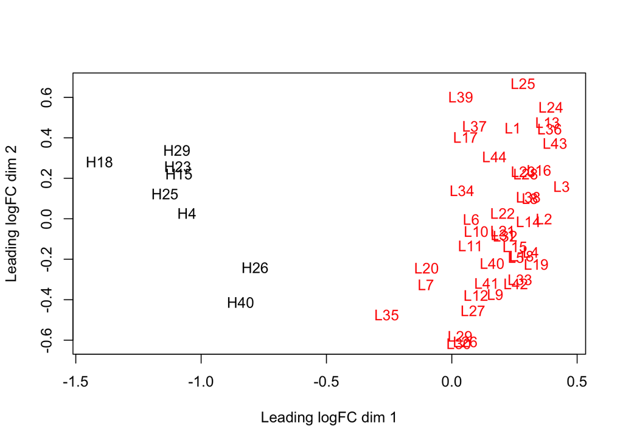

```r
# plotMDS
plotMDS(d, col = as.numeric(group))
```

```r
mm <- model.matrix(~0 + group)
y <- voom(d, mm, plot = F)
```

**2. Fitting linear models in limma**

```
##             groupH   groupL
## ARHGEF10L 6.417804 6.292352
## HIF3A     5.578579 5.704528
## RNF17     2.587710 2.175131
## RNF10     6.531101 6.481992
## RNF11     6.405865 6.360107
## RNF13     6.276897 6.312033
```

```
##         Contrasts
## Levels   groupH - groupL
##   groupH               1
##   groupL              -1
```

```
##               logFC  AveExpr        t      P.Value    adj.P.Val        B
## NXF2B     3.5313160 2.645357 30.00359 4.965510e-35 9.838164e-31 62.11409
## NXF2      3.5399163 2.952817 26.42051 2.844247e-32 2.817653e-28 58.92364
## NXF5      2.7327294 2.418185 24.17096 2.267921e-30 1.497810e-26 46.71039
## PDZD4     0.6876036 5.856345 23.49046 9.125342e-30 4.520010e-26 57.65177
## REEP2     0.8256956 5.757480 20.62408 4.738762e-27 1.877782e-23 51.42473
## NACAD     0.6017432 5.857771 20.42331 7.531685e-27 2.487088e-23 50.95089
## PEMT      0.5357156 6.040809 20.32017 9.569289e-27 2.708519e-23 50.63844
## BRSK1     0.6607140 5.695319 20.21246 1.229985e-26 3.046211e-23 50.47077
## SNPH      0.5665285 5.876628 20.05864 1.763504e-26 3.882256e-23 50.09571
## MSI1      0.9290058 5.537689 19.84171 2.941960e-26 5.828905e-23 49.55924
## SLC26A11  0.4844273 5.963762 18.79648 3.683136e-25 6.633997e-22 47.01640
## C12orf34  0.8253707 5.720820 18.73422 4.295598e-25 7.092391e-22 46.93745
## COQ10A    0.3924477 5.834317 18.66005 5.162157e-25 7.428907e-22 46.74748
## ZNF483    0.9860845 5.162728 18.63294 5.521565e-25 7.428907e-22 46.26943
## PPP1R3F   0.5915265 5.732650 18.62552 5.624268e-25 7.428907e-22 46.67060
## RAB3A     0.7355344 5.642702 18.49087 7.865980e-25 9.156086e-22 46.33806
## NAPB      0.4132344 6.055156 18.47675 8.148457e-25 9.156086e-22 46.17496
## PELI3     0.4513443 5.982594 18.46850 8.318253e-25 9.156086e-22 46.19144
## LOC338758 0.7346432 5.385806 18.42778 9.210344e-25 9.604450e-22 46.01910
## RND2      0.8988340 5.378086 18.27382 1.355948e-24 1.343270e-21 45.68502
## ICA1L     0.5778937 5.741490 18.19910 1.637276e-24 1.544731e-21 45.60440
## SLC25A14  0.3215260 5.896718 17.94652 3.109945e-24 2.800788e-21 44.93961
## EID2B     0.6092317 5.513461 17.81353 4.371288e-24 3.765579e-21 44.58331
## MAP6      0.6193567 5.899867 17.76668 4.930353e-24 4.070212e-21 44.43544
## SPTBN4    1.0107248 5.528402 17.74560 5.205133e-24 4.125172e-21 44.44916
## C5orf55   0.5085118 5.598061 17.72839 5.440931e-24 4.146198e-21 44.39435
## PRRT3     0.6031418 5.743525 17.54527 8.735125e-24 6.409964e-21 43.93205
## SYP       0.9167056 5.865919 17.50903 9.596832e-24 6.790787e-21 43.77739
## MPP2      0.7606138 5.706708 17.49397 9.980111e-24 6.818481e-21 43.80351
## LOC401431 0.8792522 5.330989 17.39580 1.288863e-23 8.512084e-21 43.43810
```

Low survival correlated gene log(FC)<-0 and FDR <0.05, top 10 genes:

```
##              logFC  AveExpr         t      P.Value    adj.P.Val        B
## ZFP36L1 -0.3783114 6.577546 -11.98812 9.546850e-17 5.892577e-15 27.44137
## ZFP36L2 -0.2734283 6.566572 -11.75817 2.028018e-16 1.161304e-14 26.62670
## S100A11 -0.5117513 6.649320 -11.61134 3.292591e-16 1.802102e-14 26.22610
## LITAF   -0.2551301 6.504180 -11.29464 9.452866e-16 4.658946e-14 25.10917
## ANXA2P2 -0.4738954 6.605553 -11.29387 9.477329e-16 4.659412e-14 25.17222
## IL4R    -0.3677099 6.385476 -11.08625 1.905211e-15 8.697684e-14 24.62394
## TUBA1C  -0.3753235 6.469022 -11.03874 2.237022e-15 1.002763e-13 24.36568
## ANXA2   -0.4010428 6.777055 -11.00462 2.510883e-15 1.112934e-13 24.02232
## STK38   -0.2657788 6.319704 -10.97349 2.790131e-15 1.225740e-13 24.21501
## SP100   -0.3308664 6.373819 -10.95723 2.948319e-15 1.278228e-13 24.16141
```

## Overlapping between correlation analysis and DEG analysis

Venn diagram showed 196 overlapping genes between DEG dataset and correlation dataset.

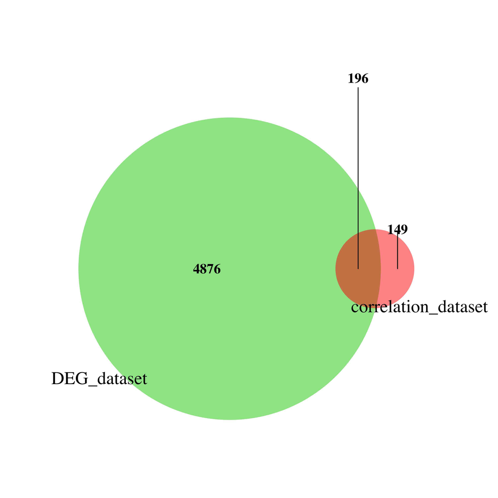

## GO and KEGG Analysis

```
##   ENTREZID         ENSEMBL SYMBOL
## 1     4312 ENSG00000196611   MMP1
## 2     8318 ENSG00000093009  CDC45
```

```
##            ONTOLOGY         ID              Description GeneRatio   BgRatio
## GO:0042110       BP GO:0042110        T cell activation    55/181 376/11248
## GO:0002250       BP GO:0002250 adaptive immune response    46/181 319/11248
##                  pvalue     p.adjust       qvalue
## GO:0042110 3.886363e-38 7.982589e-35 6.144544e-35
## GO:0002250 2.244761e-31 2.305370e-28 1.774543e-28
##                                                                                                                                                                                                                                                                                                          …
## GO:0042110 WAS/FUT7/SIT1/IFNG/RHOH/LILRB1/DOCK2/CD74/ICOS/CD3D/CD40LG/TNFRSF1B/CTLA4/LILRB2/CD28/SIRPG/PTPRC/CD7/TNFSF8/GPR18/HLA-DPA1/CD2/PDCD1/CD8A/PLA2G2D/PDCD1LG2/PIK3CD/FOXP3/BTN2A2/CD3E/AIF1/LCP1/IRF4/HLA-E/CD3G/CD27/IL7R/ITGAL/CD4/NCKAP1L/LY9/CORO1A/IL12RB1/HLA-DPB1/CCL5/LILRB4/CD8B/CD86/H…
## GO:0002250                                                               WAS/IL18BP/LAIR1/SIT1/LILRB1/CD74/CD244/CD3D/CD40LG/TNFRSF1B/CTLA4/LILRB2/CD48/CD28/PTPRC/CD7/SLAMF1/CD247/LTA/TRAT1/PDCD1/PDCD1LG2/PIK3CD/FOXP3/CD3E/SH2D1A/BTK/PRF1/C1QA/IRF4/HLA-E/CD3G/SAMSN1/CD27/IL7R/CD4/BTN3A3/LY9/IL12R…
##            Count
## GO:0042110    55
## GO:0002250    46
```

### Gene Ontology Molecular Function

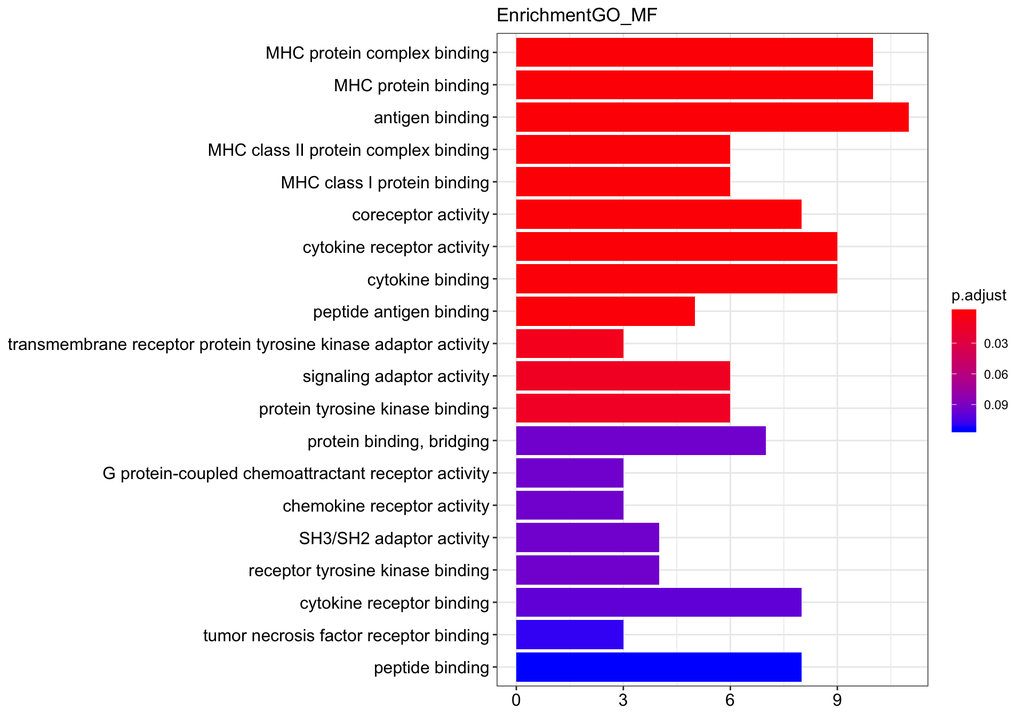

### Gene Ontology Biology Process

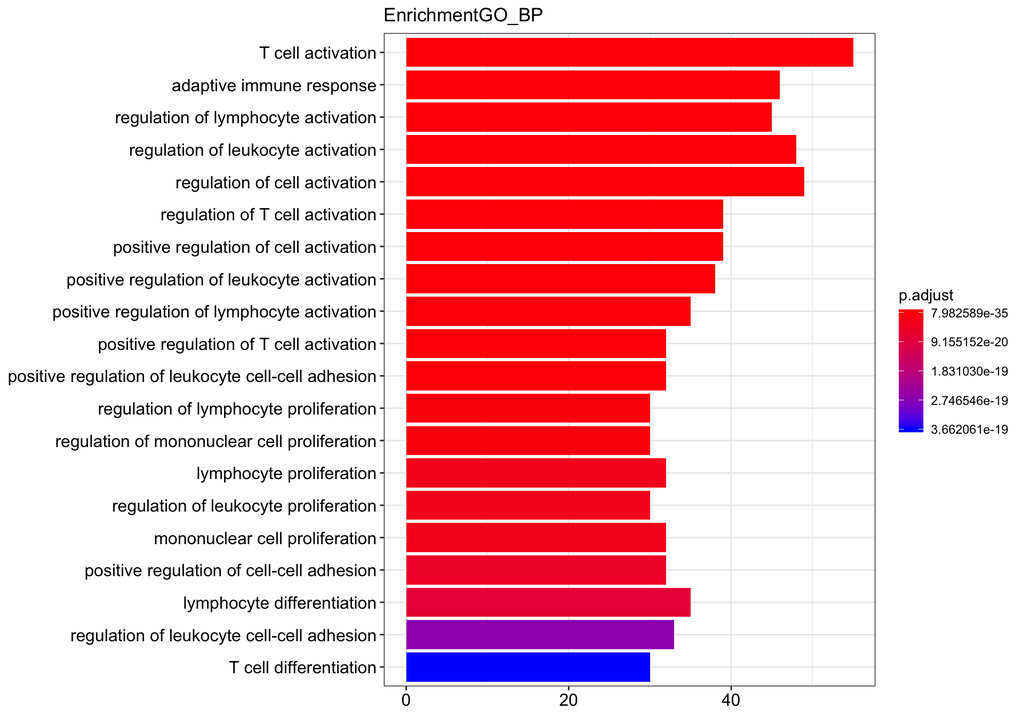

### Gene Ontology Cellular Component

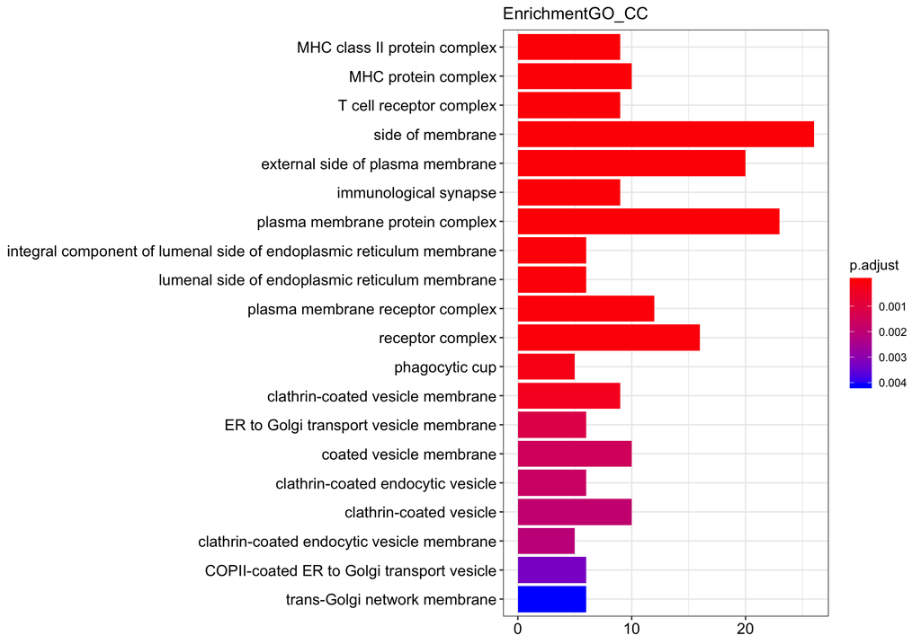

### KEGG Pathway

```
##                ID                    Description GeneRatio  BgRatio
## hsa04514 hsa04514 Cell adhesion molecules (CAMs)    26/110 147/7946
## hsa04640 hsa04640     Hematopoietic cell lineage    22/110  99/7946
## hsa05330 hsa05330            Allograft rejection    16/110  38/7946
## hsa05332 hsa05332      Graft-versus-host disease    16/110  41/7946
## hsa04940 hsa04940       Type I diabetes mellitus    16/110  43/7946
## hsa04659 hsa04659      Th17 cell differentiation    21/110 107/7946
##                pvalue     p.adjust       qvalue
## hsa04514 2.985632e-22 4.986006e-20 3.865608e-20
## hsa04640 3.473792e-21 2.900616e-19 2.248823e-19
## hsa05330 1.019950e-20 5.677723e-19 4.401891e-19
## hsa05332 4.570506e-20 1.908186e-18 1.479401e-18
## hsa04940 1.149689e-19 3.839960e-18 2.977089e-18
## hsa04659 4.823876e-19 1.342646e-17 1.040942e-17
##                                                                                                                                 geneID
## hsa04514 29851/3123/3108/959/1493/940/5788/3113/914/5133/925/3385/80380/3122/3133/3117/3683/920/3112/3115/201633/926/942/3109/3111/923
## hsa04640                             915/3123/3108/924/3113/914/925/952/916/3122/3117/917/3575/920/3112/3115/951/926/921/3109/3111/912
## hsa05330                                                  3458/3123/3108/959/940/3113/5551/3122/3133/3117/3112/3115/3002/942/3109/3111
## hsa05332                                                 3458/3123/3108/940/3113/3824/5551/3122/3133/3117/3112/3115/3002/942/3109/3111
## hsa04940                                                 3458/3123/3108/940/3113/4049/5551/3122/3133/3117/3112/3115/3002/942/3109/3111
## hsa04659                        3458/915/3123/50615/3108/3113/919/50943/3560/916/3662/3122/3117/917/920/3112/3594/3115/3109/3111/30009
##          Count
## hsa04514    26
## hsa04640    22
## hsa05330    16
## hsa05332    16
## hsa04940    16
## hsa04659    21
```

```
## wrong orderBy parameter; set to default `orderBy = "x"`
```

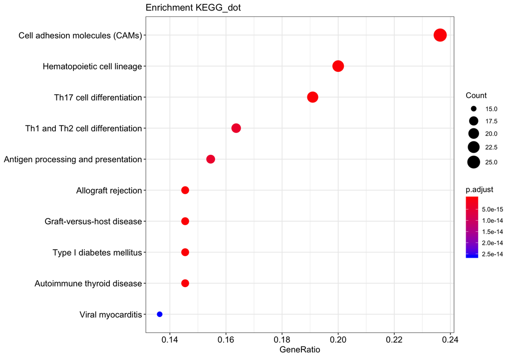

```
## Info: Working in directory /Users/zhouyufan/Documents/Study/2019 Fall/BMIN 503/BMIN503_Final_Project
```

```
## Info: Writing image file hsa04659.pathview.png
```

## Correlation Results

### Heatmap

**Biomarkers: CD8A, HAVCR2, LAG3, PDCD1, EOMES, TBX21,CTLA4**

Example gene: **TNFRSF1B** was used to show the correlation result

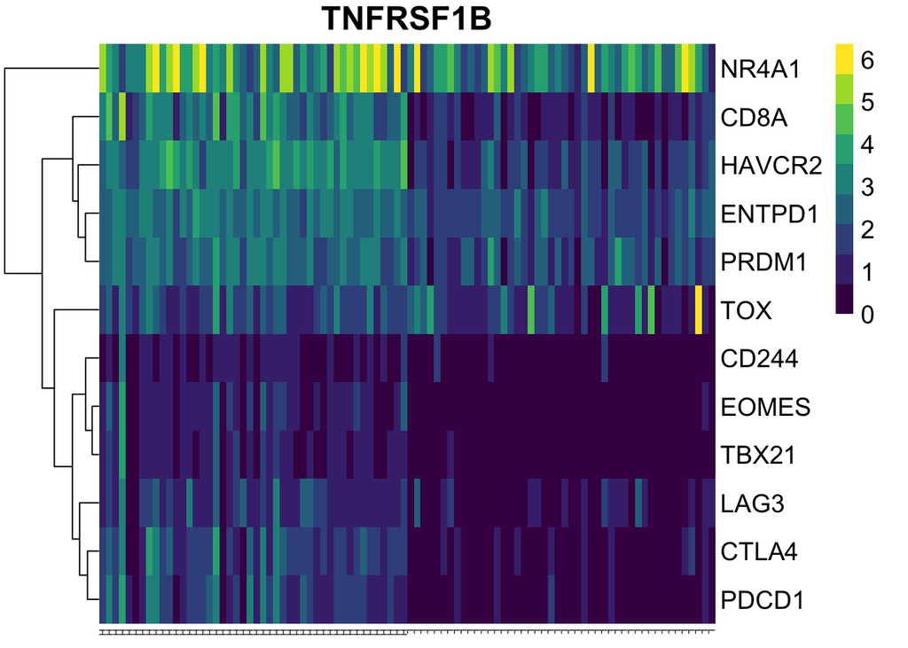

Heatmap of a selected gene potentially effect T cell dysfunction in pancreatic patients from TCGA pancreatic cohort, exhibiting high (75th percentile) and low(25th percentile) TNFRSF1B expression

### Scatter plot

Scatter plot showed the positive correlation between TNFRSF1B with CTLA4.

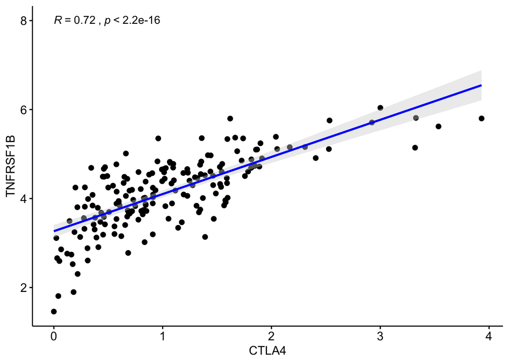

## Survival analysis

### Data prepration

```
## [1] 182 256
```

### Result

Kaplan–Meier curves were constructed by dividing specimens at the one standard deviation above or below average expression of each selected gene.

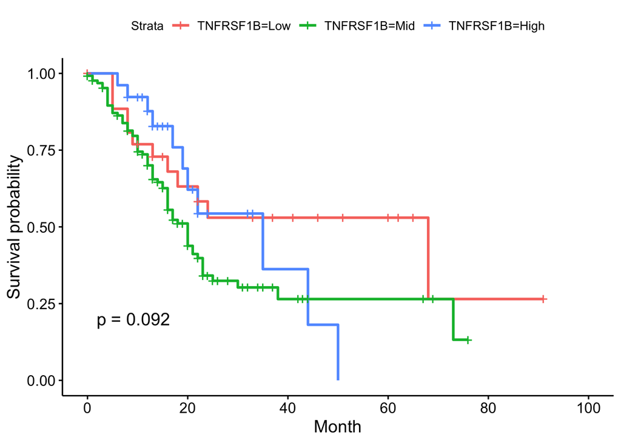

## Limitation

- One limitation of this study is I only focused on TCGA tumor dataset, by using CAR T cell clinical trials dataset to further evaluate correlation results were necessary.
- Another limitation is that I focused primarily on gene expression biomarkers. However, other data types can also predict T cell dysfunction, like epigenetic and proteomic datasets.